# STAT 311 – Lab 4

Group 17

Steven Tran & Owen Cheung

Wednesday, August 10, 2022 @ 11:59pm

Throughout this assignment, please use comments to explain what your code is doing. To make a comment in a code chunk, start the line with `#`. An example of this can be seen below.

```r
# I am going to print a comment
print("a comment")
```

```
## [1] "a comment"
```

## Question 1: Pew Research

In a Pew Research Center poll of 745 randomly selected American adults, 589 said that it is morally wrong to not report all income on tax returns.

### Part a)

The parameter of interest, or the people making up the population of interest is the proportion of all American adults who said that it is morally wrong to not report all income on tax returns. We want to learn from the population if the true proportion is different from 589 / 745.

### Part b)

phat <- 589 / 745

n <- 745

SE <- sqrt(phat * (1 - phat) / n)

multiplier <- 2.33

lower <- round(phat - multiplier*SE,3)

upper <- round(phat + multiplier*SE,3)

We are 98% confident that the true proportion of American adults who say that it is morally wrong to not report all income on tax returns to be between 0.756 to 0.825 $ (0.756, 0.825) $.

$ (0.756, 0.825) $

# Here, I’m taking the z score from the 98% confidence and multiplying it by the formula shown below.

$ n = ((2.33 * sqrt(0.5*0.5)) / 0.02)^2 $

$ n = 3394$

The sample size of adults would need to be at least 3394 in order to be 98% confident that the margin of error is 0.02.

## Question 2: Type 1 and Type 2 Errors

### Part a)

#### i)

Yes, it is possible for either J or T to make a type 1 error. For J and T, this would mean rejecting the null hypothesis that the proportion of adults in their neighborhood who have graduated from high school is equal to 0.94 when that proportion is indeed true.

Both are equally likely to make a type 1 error since this error only depends on the value of $alpha and the sample size doesn’t really matter in this case.

#### ii)

No, it isn’t possible for either J or T to make a type 2 error. This means that J and T reject the alternative hypothesis that the proportion of adults in their neighborhood who’ve graduated from high school does not equal to 0.94, when the proportion truly isn’t equal to 0.94. However, we know that the proportion truly is equal to 0.94.

J is more likely to make a type 2 error since his sample size of 200 is a lot smaller than T’s sample size of 500. This is because the error rate decreases as the sample size increases. It wouldn’t really matter in this case though, because IT IS IMPOSSIBLE TO MAKE A TYPE 2 ERROR HERE.

### Part b)

#### i)

It is not possible for either J or T to make a Type 1 error since we know that the null hypothesis that the newspaper’s proportion of adults in their neighborhood who took chemistry of 0.25 is incorrect in the first place so even if we reject the null hypothesis, it isn’t true to begin with to make that error.

Type 1 error is also dependent in $alpha and not sample size so since they both have the same alpha value, they have equal likelihood of commiting an error if it was possible. It isn’t in this case.

#### ii)

Yes, it is possible for either J or T to make a type 2 error. This means that J and T reject the alternative hypothesis that the proportion of adults in their neighborhood who’ve taken high school chemostry from high school does not equal to 0.25, when the proportion truly isn’t equal to 0.94.

J is more likely to make a type 2 error since his sample size of 200 is a lot smaller than T’s sample size of 500. This is because the error rate decreases as the sample size increases.

## Question 3: Confidence Intervals and Hypothesis Testing for a Proportion

### Exercise 1

### Exercise 2

### Exercise 3

```r
#nc_smoker <-    # fill in the rest of the code

nc_smoker <- nc %>% filter(habit == "smoker")
```

### Exercise 4

phat <- 0.143

n <- length(nc_smoker$lowbirthweight)

SE <- sqrt(phat * (1 - phat) / n)

multiplier <- 1.96

lower <- round(phat - multiplier*SE,3)

upper <- round(phat + multiplier*SE,3)

lower

upper

We are 95% confident that the true proportion of low birth weight babies born to smoking mothers lie between the interval of 0.082 to 0.204.

### Exercise 5

Null:
$$Ho: p = 0.1$$

Alternative:
$$H_a: p != 0.1$$

### Exercise 6

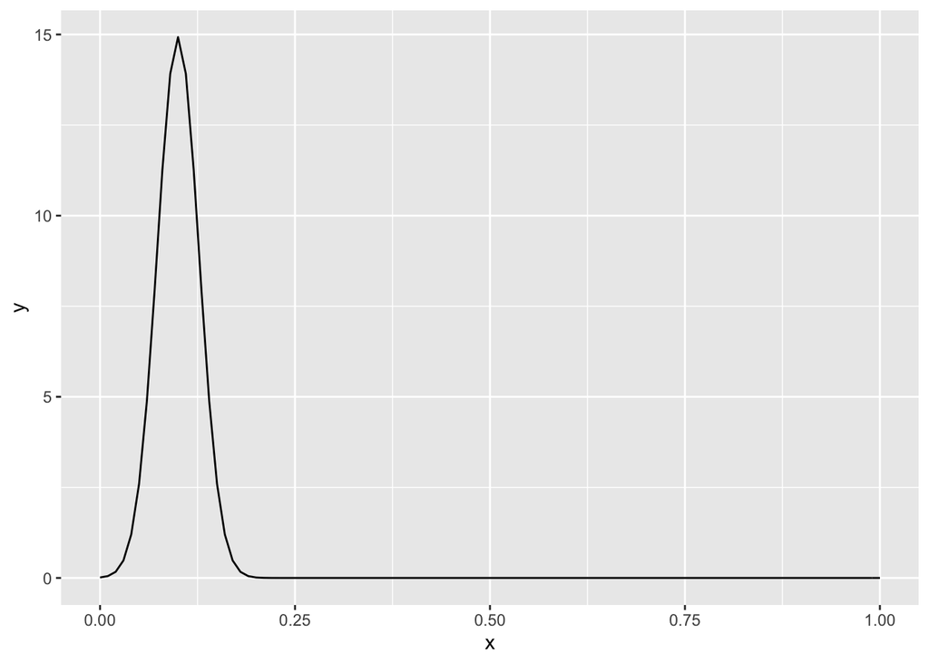

```r
# null_p <-    ## Fill in
# null_se <-   ## Fill in
# ggplot(data = NULL, aes(x = seq(0,1,by=0.01))) +
#         geom_blank() +
#         stat_function(fun = dnorm, args = c(mean = null_p, sd = null_se))


null_p <- 0.1
null_se <- sqrt(null_p * (1 - null_p) / 126)
ggplot(data = data.frame(x = seq(0,1,by=0.01)), aes(x = x)) +
        geom_blank() +
        stat_function(fun = dnorm, args = c(mean = null_p, sd = null_se))
```

### Exercise 7

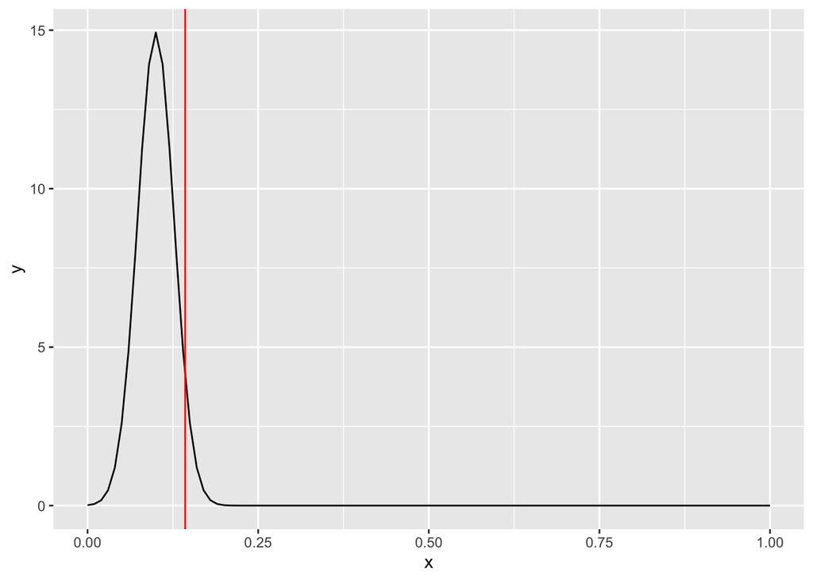

```r
phat <- 0.143
null_p <- 0.1## Fill in
null_se <- sqrt(0.1 * (1 - 0.1) / 126)## Fill in
ggplot(data = data.frame(x = seq(0,1,by=0.01)), aes(x = x)) +
        geom_blank() +
        stat_function(fun = dnorm, args = c(mean = null_p, sd = null_se)) +     geom_vline(xintercept=phat, col = "red")
```

### Exercise 8

```r
Z <- (0.143 - 0.1) / sqrt((0.1*0.9) / 126)
```

### Exercise 9

We’re now going to create a fake population of 100,000 smoking mothers where 10% of them have low birthweight babies. The code below makes a list of 100,000 0s and 1s, where 90% are 0s (normal weight baby) and 10% are 1s (underweight baby).

```r
popsize <- 100000
pop <- data.frame(lowbirthweight = c(rep(0, 0.9*popsize), rep(1, 0.1*popsize)))
```

The below code takes our population data frame and creates 10000 samples of size 126. It then computes several summary statistics for each sample. It is important to understand the meaning of each value included in the `summarise()` function below.

```r
library(infer)
set.seed(111)

p0 <- 0.1
n <- 126
true_sd <- sqrt(p0*(1-p0)/n)

results <- pop %>%
        rep_sample_n(size = 126, reps = 10000) %>%
        summarise(phat = mean(lowbirthweight),
                  se = sqrt(phat*(1-phat)/126),
                  me = 1.96 * se,
                  lower = phat - me,
                  upper = phat + me,
                  correct_CI = (lower <= p0 && upper >= p0),
                  zscore = (phat-p0)/se,
                  pval = 2*(1-pnorm(abs(zscore))),
                  reject_null = pval <= 0.05)

print(results)
```

[output not shown]

##### phat = mean(lowbirthweight)

The point estimate of this piece is the mean of the babies born with a low birth weight

phat = mean(lowbirthweight)

##### se = sqrt(phat*(1-phat)/126)

The standard error is the square route of the point estimate that we found before multiplied by 1 minus the point estimate divided by the sample size which would be 126

##### me = 1.96 * se

The margin of error is the z-score for the specific confidence interval we are going for which would be a 95% confidence level multiplied by the standard error we found.

##### lower = phat - me

The lower bound would be the point estimate minus the margin of error

##### correct_CI = (lower <= p0 && upper >= p0)

Correct CI tells us if the confidence interval was correct by checking if the lower bound was less than or equal to the null value as well as checking if the upper bound is greater than or equal to the null value

##### zscore = (phat-p0)/se

The z-score would be the point estimate minus the null value divided by the standard error

##### pval = 2*(1-pnorm(abs(zscore)))

The p value would be 2 times 1 minus the probability(pnorm of the z-score) which indicates that this is a 2 tailed test

##### reject_null = pval <= 0.05)

Reject null determines if we reject the null hypothesis by checking if the p value was less than or equal to 0.05

### Exercise 10

The smallest sample proportion I observed was 0.01587.

summary(results$phat)

min(results$phat) max(results$phat)

summary(results$zscore)